# Is Ignorance Truly Bliss? Relationship between Education, Gender & Happiness

Author

Ece Cavusgil

# 1. Project Overview and Scope

[figure not shown]

The phrase “**Ignorance is bliss** is a perspective that most of us have come across at least once, and sometimes even found meaningful. Naturally, individuals may have developed and educated themselves regardless of their formal educational background, gaining the ability to view life from different perspectives. However, in this study, the concept of ‘ignorance’ that I aim to focus on is independent of such interpretations. Instead, it refers to the relationship between a person’s level of education and their happiness, as well as how this relationship differs between men and women.

**Problem Definition**: Life satisfaction among individuals may vary depending on factors such as gender and education level. Therefore, it is necessary to conduct an analysis to examine the direction and magnitude of this interaction and to observe how happiness levels change based on individuals’ gender and educational background. **The aim** of this study is to reveal whether there is a significant relationship between educational attainment,gender and happiness levels in this context.

[**Let’s play!!!**](https://www.mentimeter.com/app/presentation/alfuqmuu3euj5y6s55iocifooenoi4vr/edit?question=gornm6irwd6a)

You can also use this code **8481 4843** on *menti.com*.

[figure not shown]

# 2. Data

[figure not shown]

## 2.1 Data Source

In this study, data obtained from the following links conducted by the Turkish Statistical Institute (TURKSTAT) has been used.

- [Life Satisfaction Survey [1]](https://www.tuik.gov.tr/)
- [Population Statistics Portal [2]](https://nip.tuik.gov.tr/)

## 2.2 General Information About Data

“**education**” dataset: This dataset contains the number of individuals by gender and educational status for each province between 2008 and 2023.A small part of the dataset is shown below.

```r
#libraries
library(readxl)
library(ggplot2)
library(tidyverse)
library(dslabs)
library(ggthemes)
library(ggrepel)
library(dplyr)
library(gganimate)
library(sf)
library(viridis)
library(broom)
library(htmlwidgets)
library(knitr)
library(gifski)
library(tidytext)
library(nortest)
library(kableExtra)
#library(DT)

#Import education dataset

#education <- read_excel("education.xlsx")
#save(education,file = "education.RData")
load("education.RData")
head(education)
```

```
# A tibble: 6 × 8
  Year  Province Educational_Status          Total   Male Female Percentage_Male
  <chr> <chr>    <chr>                       <dbl>  <dbl>  <dbl>           <dbl>
1 2023  ADANA    Okuma yazma bilmeyen        58357  10083  48274             1
2 2023  ADANA    Okuma yazma bilen fakat b… 219571  95506 124065             9.2
3 2023  ADANA    İlkokul                    441425 190047 251378            18.4
4 2023  ADANA    Ortaokul veya dengi mesle… 384900 208582 176318            20.2
5 2023  ADANA    İlköğretim                 132788  80203  52585             7.8
6 2023  ADANA    Lise veya dengi meslek ok… 484355 268172 216183            25.9
# ℹ 1 more variable: Percentage_Female <dbl>
```

“**byeducation**” dataset: This dataset contains the percentages of general happiness levels by educational status between 2004 and 2024. A small part of the dataset is shown below.

```r
#Import byeducation dataset
#byeducation <- read_excel("byeducation.xlsx")
#save(byeducation,file = "byeducation.RData")
load("byeducation.RData")
head(byeducation)
```

```
# A tibble: 6 × 7
   Year Happiness_Level           `No School Completed` `Primary  School`
  <dbl> <chr>                                     <dbl>             <dbl>
1  2004 Happy                                      54.4              57.7
2  2004 Neither happy nor unhappy                  27                30.7
3  2004 Unhappy                                    18.6              11.6
4  2005 Happy                                      54                55.2
5  2005 Neither happy nor unhappy                  27.8              31.8
6  2005 Unhappy                                    18.1              13.1
# ℹ 3 more variables: `Primary Education or Junior High School` <dbl>,
#   `High School or Equivalent` <dbl>, `Higher Education` <dbl>
```

“**bygender**” data set: This dataset contains the percentages of general happiness levels by gender between 2003 and 2024. A small part of the dataset is shown below.

```r
#Import bygender dataset
#bygender <- read_excel("bygender.xlsx")
#save(bygender,file = "bygender.RData")
load("bygender.RData")
head(bygender)
```

```
# A tibble: 6 × 5
   Year Happiness_Level           Total  Male Female
  <dbl> <chr>                     <dbl> <dbl>  <dbl>
1  2003 Very happy                 12    12.4   11.6
2  2003 Happy                      47.6  45.7   49.4
3  2003 Neither happy nor unhappy  33.2  34.1   32.2
4  2003 Unhappy                     5.6   6.2    5
5  2003 Very unhappy                1.7   1.5    1.8
6  2004 Very happy                  9.3   8.4   10.2
```

## 2.3 Reason of Choice

Even in this century, the distinction between women and men is still evident in many areas in Turkey. Undoubtedly, educating individuals is the most effective way to change the position of women in society. And perhaps, in this way, a society that has educated itself reaches the most important value for a person: **happiness**.

## 2.4 Preprocessing

The datasets used in this study will be merged to facilitate the analysis and will be organized in a way that allows easy processing by the program. If needed during the later stages of the analysis, additional datasets may be incorporated into the study. Different preprocessing steps have been applied to each dataset. The specific modifications made to each dataset are listed below in bullet points.

**Preprocessing for “[education](https://github.com/emu-hacettepe-analytics/emu660-spring2025-ecavusgil)” dataset;**

- The presence of missing values (NA) is examined, and necessary preprocessing steps are applied if they exist.
- The education levels (“Educational_Status”) in the “education” dataset (10 levels) were aligned with those in the ‘byeducation’ dataset (5 levels).
- Irrelevant information has been removed from the dataset to simplify it. For example, entries such as “Unknown” and “Total” in the “Educational_Status” column have been excluded.

```r
#changes in education dataset
#head(education)
#str(education)

 sum(is.na(education))
```

```
[1] 0
```

```r
 education<- education |> filter(!Educational_Status %in% c("Bilinmeyen","Toplam"))|>
  mutate(Educational_Status = case_when(
    Educational_Status %in% c("Okuma yazma bilmeyen", "Okuma yazma bilen fakat bir okul bitirmeyen") ~ "No School Completed",
    Educational_Status== "İlkokul" ~ "Primary School",
    Educational_Status %in% c("Ortaokul veya dengi meslek okulu", "İlköğretim") ~ "Primary Education or Junior High School",
    Educational_Status== "Lise veya dengi meslek okulu" ~ "High School or Equivalent",
    Educational_Status %in% c("Yüksekokul veya fakülte", "Yüksek lisans ve üzeri") ~ "Higher Education",
    TRUE ~ as.character(Educational_Status)))

  education<- education |>  group_by(Year,Province,Educational_Status) |>
  summarise(
    Total=sum(Total,na.rm = TRUE),
    Male=sum(Male,na.rm = TRUE),
    Female=sum(Female,na.rm = TRUE),
    Percentage_Male=sum(Percentage_Male,na.rm = TRUE),
    Percentage_Female=sum(Percentage_Female,na.rm = TRUE),
    .groups = "drop"
  )

education$Educational_Status<-factor(education$Educational_Status,levels= c("No School Completed","Primary School","Primary Education or Junior High School","High School or Equivalent","Higher Education"),ordered = TRUE)


head(education) |> kbl() |> kable_styling(full_width = 5)
```

| Year | Province | Educational_Status | Total | Male | Female | Percentage_Male | Percentage_Female |
| --- | --- | --- | --- | --- | --- | --- | --- |
| 2008 | ADANA | High School or Equivalent | 300221 | 163672 | 136549 | 19.6 | 15.8 |
| 2008 | ADANA | Higher Education | 100011 | 59440 | 40571 | 7.1 | 4.7 |
| 2008 | ADANA | No School Completed | 552668 | 229450 | 323218 | 27.5 | 37.5 |
| 2008 | ADANA | Primary Education or Junior High School | 275436 | 150951 | 124485 | 18.1 | 14.4 |
| 2008 | ADANA | Primary School | 469036 | 230288 | 238748 | 27.6 | 27.6 |
| 2008 | ADIYAMAN | High School or Equivalent | 62867 | 39780 | 23087 | 16.8 | 9.5 |

```r
#datatable(education,filter = "top",options = list(pageLength = 5))
```

The variables and their corresponding value ranges in the finalized “education” dataset are defined as follows:

```r
 str(education)
```

```
tibble [6,480 × 8] (S3: tbl_df/tbl/data.frame)
 $ Year              : chr [1:6480] "2008" "2008" "2008" "2008" ...
 $ Province          : chr [1:6480] "ADANA" "ADANA" "ADANA" "ADANA" ...
 $ Educational_Status: Ord.factor w/ 5 levels "No School Completed"<..: 4 5 1 3 2 4 5 1 3 2 ...
 $ Total             : num [1:6480] 300221 100011 552668 275436 469036 ...
 $ Male              : num [1:6480] 163672 59440 229450 150951 230288 ...
 $ Female            : num [1:6480] 136549 40571 323218 124485 238748 ...
 $ Percentage_Male   : num [1:6480] 19.6 7.1 27.5 18.1 27.6 16.8 4.4 35.5 20.1 23.3 ...
 $ Percentage_Female : num [1:6480] 15.8 4.7 37.5 14.4 27.6 9.5 1.8 52.4 15 21.5 ...
```

- *Year*: The year of the study (ranging from 2008 to 2023).
- *Province*: Name of the province (81 provinces in total).
- *Educational_Status*: Education level (“No School Completed,” “Primary School,” “Primary Education or Junior High School,” “High School or Equivalent,” “Higher Education”).
- *Total*: Total number of individuals in a given year, province, and education level.
- *Male*: Number of males in a given year, province, and education level.
- *Female*: Number of females in a given year, province, and education level.
- *Percentage_Male*: Percentage of males in a given year, province, and education level.
- *Percentage_Female*: Percentage of females in a given year, province, and education level.

Descriptive statistics for variables are presented below.

```r
 summary(education)
```

```
     Year             Province
 Length:6480        Length:6480
 Class :character   Class :character
 Mode  :character   Mode  :character



                               Educational_Status     Total
 No School Completed                    :1296     Min.   :     681
 Primary School                         :1296     1st Qu.:   42114
 Primary Education or Junior High School:1296     Median :   86103
 High School or Equivalent              :1296     Mean   :  190227
 Higher Education                       :1296     3rd Qu.:  183118
                                                  Max.   :16154476
      Male             Female        Percentage_Male Percentage_Female
 Min.   :    257   Min.   :    424   Min.   : 0.00   Min.   : 0.00
 1st Qu.:  21807   1st Qu.:  19350   1st Qu.:12.70   1st Qu.:11.80
 Median :  43320   Median :  41185   Median :19.80   Median :18.70
 Mean   :  95128   Mean   :  95099   Mean   :19.45   Mean   :19.44
 3rd Qu.:  91336   3rd Qu.:  91346   3rd Qu.:25.82   3rd Qu.:25.80
 Max.   :7930608   Max.   :8223868   Max.   :54.80   Max.   :79.50
```

**Preprocessing for “[byeducation](https://github.com/emu-hacettepe-analytics/emu660-spring2025-ecavusgil)” dataset;**

- The presence of missing values (NA) is examined, and necessary preprocessing steps are applied if they exist.
- The “byeducation” dataset is updated to include data from 2008 to 2023, in accordance with the ‘education’ dataset, which contains information for the same years.
- The variable “Happiness_Level”, which indicates the level of happiness, is defined as a factor variable with three levels.

```r
#changes in byeducation dataset
#head(byeducation)
#str(byeducation)


sum(is.na(byeducation))
```

```
[1] 0
```

```r
byeducation<- byeducation |> filter(Year %in% 2008:2023)
byeducation$Happiness_Level<-factor(byeducation$Happiness_Level,levels= c("Unhappy","Neither happy nor unhappy","Happy"),ordered = TRUE)
names(byeducation)[4]<-"Primary School"

head(byeducation) |> kbl() |> kable_styling(full_width = 5)
```

| Year | Happiness_Level | No School Completed | Primary School | Primary Education or Junior High School | High School or Equivalent | Higher Education |
| --- | --- | --- | --- | --- | --- | --- |
| 2008 | Happy | 55.8 | 54.0 | 55.3 | 55.5 | 62.9 |
| 2008 | Neither happy nor unhappy | 26.3 | 31.8 | 31.7 | 33.1 | 24.6 |
| 2008 | Unhappy | 17.8 | 14.2 | 12.9 | 11.4 | 12.5 |
| 2009 | Happy | 51.8 | 52.5 | 56.1 | 54.7 | 63.2 |
| 2009 | Neither happy nor unhappy | 27.3 | 32.8 | 32.3 | 32.4 | 27.8 |
| 2009 | Unhappy | 21.0 | 14.7 | 11.6 | 13.0 | 9.0 |

The variables and their corresponding value ranges in the finalized “byeducation” dataset are defined as follows:

```r
 str(byeducation)
```

```
tibble [48 × 7] (S3: tbl_df/tbl/data.frame)
 $ Year                                   : num [1:48] 2008 2008 2008 2009 2009 ...
 $ Happiness_Level                        : Ord.factor w/ 3 levels "Unhappy"<"Neither happy nor unhappy"<..: 3 2 1 3 2 1 3 2 1 3 ...
 $ No School Completed                    : num [1:48] 55.8 26.3 17.8 51.8 27.3 21 56.3 28.9 14.8 57.2 ...
 $ Primary School                         : num [1:48] 54 31.8 14.2 52.5 32.8 14.7 60.5 29 10.6 61.1 ...
 $ Primary Education or Junior High School: num [1:48] 55.3 31.7 12.9 56.1 32.3 11.6 61.6 27.6 10.8 64.4 ...
 $ High School or Equivalent              : num [1:48] 55.5 33.1 11.4 54.7 32.4 13 62.7 27.1 10.1 63.9 ...
 $ Higher Education                       : num [1:48] 62.9 24.6 12.5 63.2 27.8 9 67.7 26.2 6.1 66.7 ...
```

- *Year*: The study year (ranging from 2008 to 2023).
- *Happiness_Level*: Levels of happiness (“Unhappy,” “Neither Happy nor Unhappy,” “Happy”).
- *No School Completed*: The percentage of individuals with no formal education for a given year and happiness level.
- *Primary School*: The percentage of individuals who completed primary school for a given year and happiness level.
- *Primary Education or Junior High School*: The percentage of individuals who completed primary education or junior high school for a given year and happiness level.
- *High School or Equivalent*: The percentage of individuals who completed high school or its equivalent for a given year and happiness level.
- *Higher Education*: The percentage of individuals who completed university or higher education for a given year and happiness level.

Descriptive statistics for the variables are as follows:

```r
 summary(byeducation)
```

```
      Year                       Happiness_Level No School Completed
 Min.   :2008   Unhappy                  :16     Min.   :11.66
 1st Qu.:2012   Neither happy nor unhappy:16     1st Qu.:16.40
 Median :2016   Happy                    :16     Median :28.20
 Mean   :2016                                    Mean   :33.33
 3rd Qu.:2019                                    3rd Qu.:54.37
 Max.   :2023                                    Max.   :63.54
 Primary School  Primary Education or Junior High School
 Min.   :10.10   Min.   : 7.90
 1st Qu.:14.18   1st Qu.:13.27
 Median :32.25   Median :32.47
 Mean   :33.34   Mean   :33.33
 3rd Qu.:52.33   3rd Qu.:52.39
 Max.   :62.94   Max.   :64.40
 High School or Equivalent Higher Education
 Min.   : 8.10             Min.   : 6.10
 1st Qu.:13.36             1st Qu.:12.91
 Median :33.03             Median :31.32
 Mean   :33.33             Mean   :33.33
 3rd Qu.:50.88             3rd Qu.:51.57
 Max.   :63.90             Max.   :67.70
```

**Preprocessing for “[bygender](https://github.com/emu-hacettepe-analytics/emu660-spring2025-ecavusgil)” dataset;**

- The presence of missing values (NA) is examined, and necessary preprocessing steps are applied if they exist.
- The “bygender” dataset is updated to include data from 2008 to 2023, in accordance with the ‘education’ dataset, which contains information for the same years.
- Happiness levels in this dataset were originally assessed on five different levels. For the consistency of the analysis, the levels of happiness have been redefined and consolidated into three levels, similar to the categorization in the “bygender” dataset.

```r
#changes in bygender dataset
#head(bygender)
#str(bygender)

sum(is.na(bygender))
```

```
[1] 0
```

```r
bygender <- bygender |> filter(Year %in% 2008:2023)|>
  mutate(Happiness_Level = case_when(
    Happiness_Level %in% c("Very happy", "Happy") ~ "Happy",
    Happiness_Level %in% c("Very unhappy", "Unhappy") ~ "Unhappy",
    Happiness_Level== "Neither happy nor unhappy" ~ "Neither happy nor unhappy",
    TRUE ~ as.character(Happiness_Level)))

  bygender<- bygender |> group_by(Year,Happiness_Level)|>
  summarise(
    Total=sum(Total,na.rm = TRUE),
    Male=sum(Male,na.rm = TRUE),
    Female=sum(Female,na.rm = TRUE),
    .groups = "drop"
  )

bygender$Happiness_Level<-factor(bygender$Happiness_Level,levels= c("Unhappy","Neither happy nor unhappy","Happy"),ordered = TRUE)


head(bygender) |> kbl() |> kable_styling(full_width = 5)
```

| Year | Happiness_Level | Total | Male | Female |
| --- | --- | --- | --- | --- |
| 2008 | Happy | 55.7 | 53.7 | 57.8 |
| 2008 | Neither happy nor unhappy | 30.3 | 30.7 | 30.0 |
| 2008 | Unhappy | 13.9 | 15.7 | 12.2 |
| 2009 | Happy | 54.3 | 50.3 | 58.1 |
| 2009 | Neither happy nor unhappy | 31.1 | 32.7 | 29.6 |
| 2009 | Unhappy | 14.6 | 17.1 | 12.3 |

The variables and their corresponding value ranges in the finalized “bygender” dataset are defined as follows:

```r
 str(bygender)
```

```
tibble [48 × 5] (S3: tbl_df/tbl/data.frame)
 $ Year           : num [1:48] 2008 2008 2008 2009 2009 ...
 $ Happiness_Level: Ord.factor w/ 3 levels "Unhappy"<"Neither happy nor unhappy"<..: 3 2 1 3 2 1 3 2 1 3 ...
 $ Total          : num [1:48] 55.7 30.3 13.9 54.3 31.1 14.6 61.2 28.1 10.8 62.1 ...
 $ Male           : num [1:48] 53.7 30.7 15.7 50.3 32.7 17.1 59.6 28.9 11.5 59.5 ...
 $ Female         : num [1:48] 57.8 30 12.2 58.1 29.6 12.3 62.7 27.3 10 64.6 ...
```

Descriptive statistics for the variables are as follows:

```r
 summary(bygender)
```

```
      Year                       Happiness_Level     Total
 Min.   :2008   Unhappy                  :16     Min.   : 9.90
 1st Qu.:2012   Neither happy nor unhappy:16     1st Qu.:14.35
 Median :2016   Happy                    :16     Median :31.55
 Mean   :2016                                    Mean   :33.33
 3rd Qu.:2019                                    3rd Qu.:52.40
 Max.   :2023                                    Max.   :62.10
      Male           Female
 Min.   :10.50   Min.   : 9.10
 1st Qu.:16.75   1st Qu.:12.18
 Median :34.05   Median :29.70
 Mean   :33.34   Mean   :33.34
 3rd Qu.:48.10   3rd Qu.:55.58
 Max.   :59.60   Max.   :64.60
```

# 3. Analysis

[figure not shown]

## 3.1 Exploratory Data Analysis

At this stage of the analysis, visualizations will be used to explore the data in more detail, aiming to gain insights into the characteristics of different variables. To ensure a more structured analysis process, the datasets will be examined one by one in sequence. For each dataset, a set of questions will be explored with the aim of gaining deeper understanding and shedding light on key patterns.

To provide a more detailed analysis of the “education” dataset, the following questions will be examined.

Examining the provinces and years with a high number of individuals holding higher education degrees or no formal education may offer meaningful insights into educational disparities. *Question: Which are the top 10 provinces with the highest number of university graduates, and which are the top 10 provinces with the highest number of individuals who have not completed any formal education?*

Based on the graphs presented below, the following observations can be made:

- The number of individuals with higher education has steadily **increased** over the years.
- The provinces with the highest levels of higher education attainment remain relatively consistent over time, with major cities such as **Istanbul**, **Ankara**, and **Izmir** standing out.
- This trend may be attributed to both the larger populations in these cities and the higher concentration of universities located there.

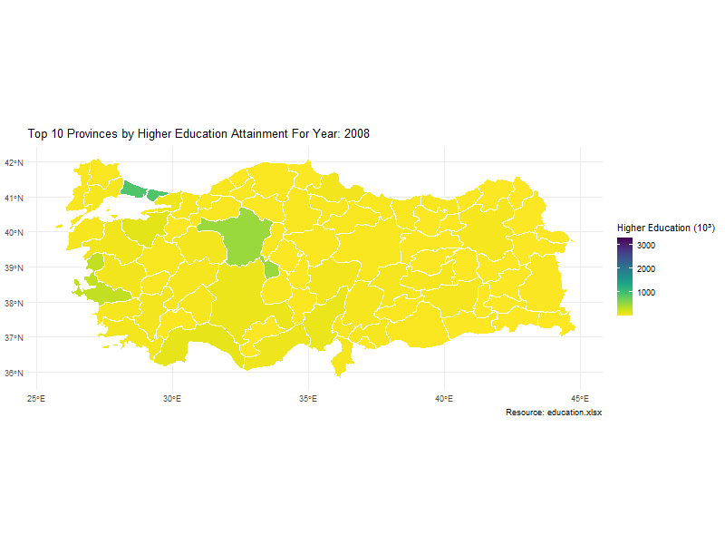

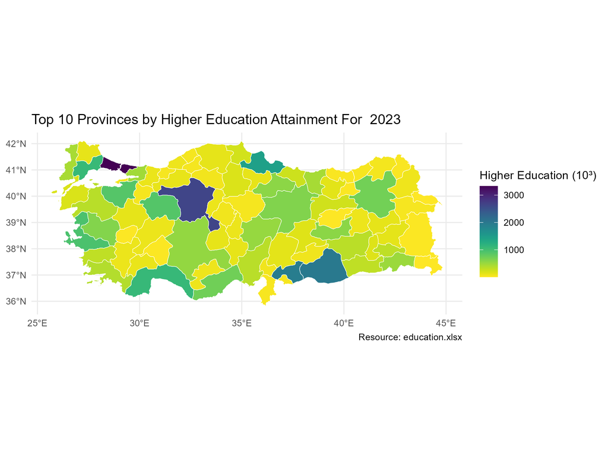

```r
include_graphics("higher_education_static.png")
```

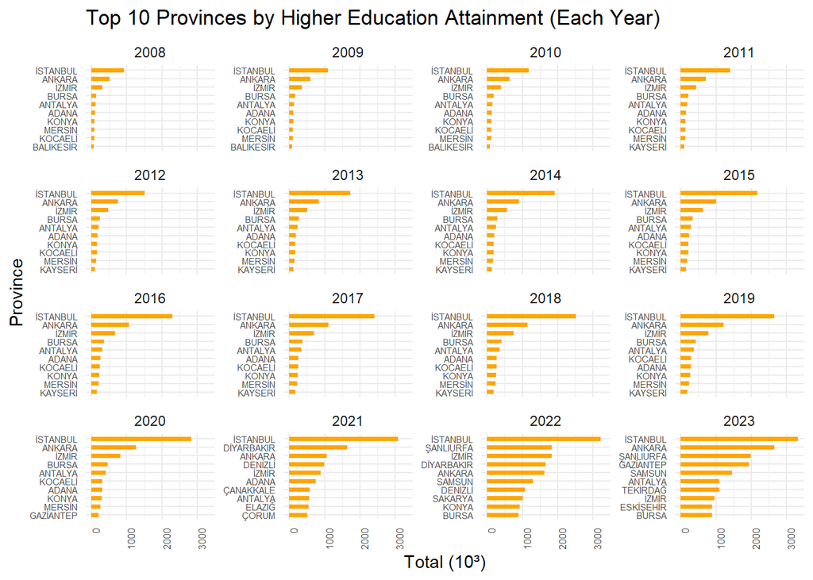

```r
#Top 10 Provinces by Higher Education Attainment (Each Year)
education |>
  filter(Educational_Status == "Higher Education") |>
  group_by(Year) |>
  slice_max(order_by = Total, n = 10) |>
  ungroup() |>
  ggplot(aes(x = reorder_within(Province, Total,Year), y = Total / 1000,width = 0.5)) +
  geom_bar(stat = "identity", fill = "orange") +
  coord_flip() +
  facet_wrap(~Year, scales = "free_y") +
  scale_x_reordered() +
  labs(
    title = "Top 10 Provinces by Higher Education Attainment (Each Year)",
    x = "Province",
    y = "Total (10³)"
  ) +
  theme_minimal()+
  theme(axis.text.x = element_text(angle = 90, hjust = 1, size = 6),axis.text.y= element_text(size=5.5))
```

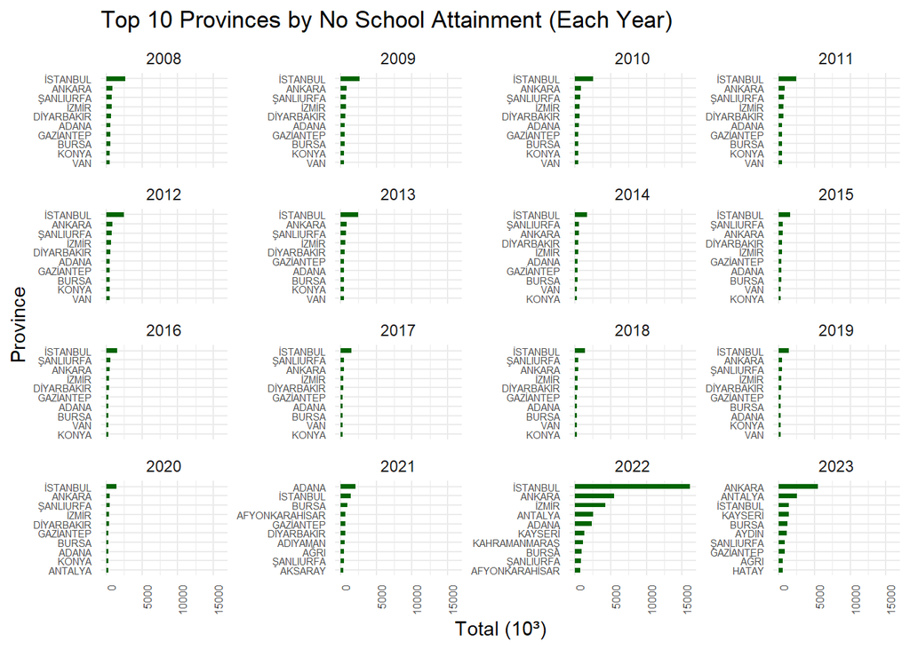

```r
education |>
  filter(Educational_Status == "No School Completed") |>
  group_by(Year) |>
  slice_max(order_by = Total, n = 10) |>
  ungroup() |>
  ggplot(aes(x = reorder_within(Province, Total,Year), y = Total/1000 ,width = 0.5)) +
  geom_bar(stat = "identity", fill = "darkgreen") +
  coord_flip() +
  facet_wrap(~Year, scales = "free_y") +
  scale_x_reordered() +
  labs(
    title = "Top 10 Provinces by No School Attainment (Each Year)",
    x = "Province",
    y = "Total (10³)"
  ) +
  theme_minimal()+
  theme(axis.text.x = element_text(angle = 90, hjust = 1, size = 6),axis.text.y= element_text(size=5.5))
```

After examining the number of individuals with no formal education and those with higher education across provinces, the next step involves incorporating the gender dimension into the analysis. *Question: What does the comparison between female and male proportions tell us about the presumed educational disadvantage faced by women?*

Below, a series of maps illustrate the percentage of women and men with no formal education across provinces over time. The visualizations show that, in recent years, the number of **men with no education has begun to surpass that of women** in many provinces.

Does this observation indicate that the educational disadvantage has shifted over time to affect men more significantly?

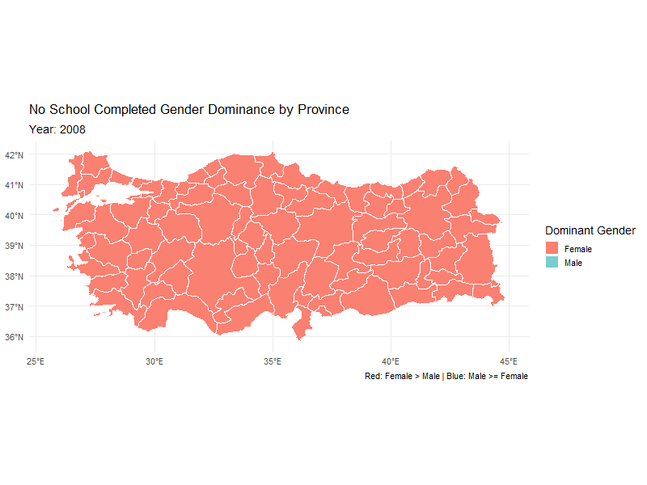

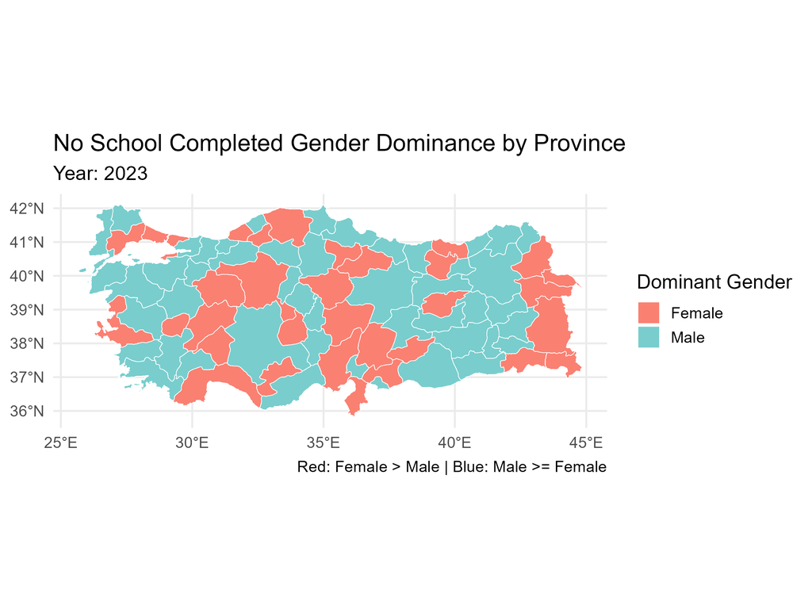

```r
include_graphics("female_male_static.png")
```

To further investigate the findings from the map above, we can examine the gender distribution across different education levels (aggregated for all years at the national level) using the chart below.

Contrary to our earlier observation, the chart reveals that **57.48%** of individuals with no formal education are **women**.

So, what do these seemingly conflicting results actually tell us?

They suggest that, overall, the number of **women who have never received any formal education is significantly higher than that of men**, even if recent trends indicate a growing number of uneducated men in certain regions.

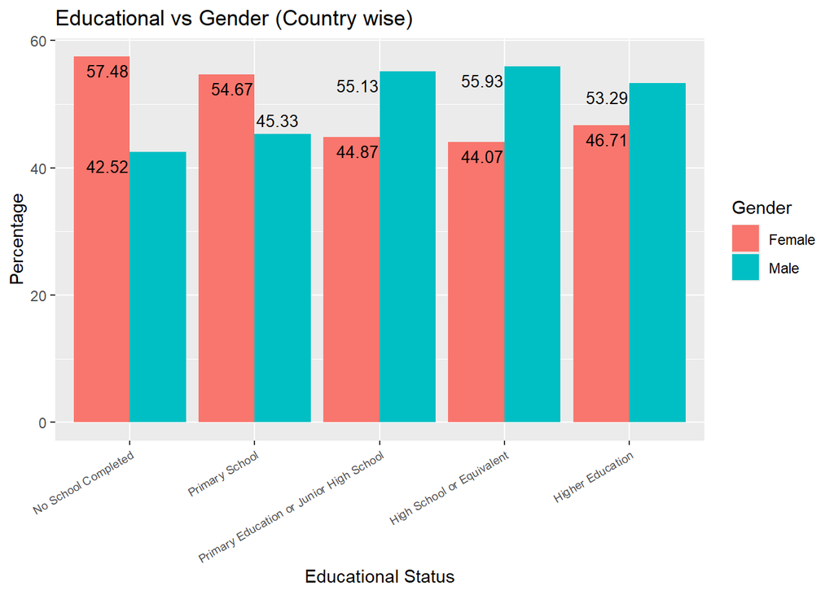

```r
 education |> group_by(Educational_Status)  |>
  summarise(Male = sum(Male),
            Female = sum(Female)) |> mutate(Total = Male + Female,
         Male = Male / Total * 100,
         Female = Female / Total * 100) |>
  pivot_longer(cols = c("Male", "Female"), names_to = "Gender", values_to = "Percentage") |>
  ggplot(aes(x = Educational_Status, y = Percentage, fill = Gender)) +
  geom_bar(stat = "identity", position = "dodge") +
  labs(title = "Educational vs Gender (Country wise)", x = "Educational Status", y = "Percentage")+geom_text_repel(aes(label =round(Percentage,2)), color = "black", size = 3.5)+
  theme(axis.text.x = element_text(angle = 30, hjust = 1, size = 7))
```

To provide a more detailed analysis of the “byeducation” dataset, the following questions will be examined.

To closely examine this dataset, the first step is to explore the relationship between education levels and life satisfaction. *Question: Which education level group reports higher life satisfaction, and which one reports the lowest?*

Based on the results obtained, the following observations can be made:

- Within a given year, the distribution of education levels across happiness categories shows relatively similar proportions.
- Individuals with **higher education** have the **highest** average life satisfaction “Happy”, whereas those with only **primary school education** report the **lowest**.
- Among those who identify as “Unhappy,” the **largest proportion** consists of individuals with **no formal education**, while the **smallest** share belongs to those with **higher education**.
- Individuals with a high school education or with primary/junior high school education tend to display similar patterns, showing closely aligned averages across the different happiness levels.

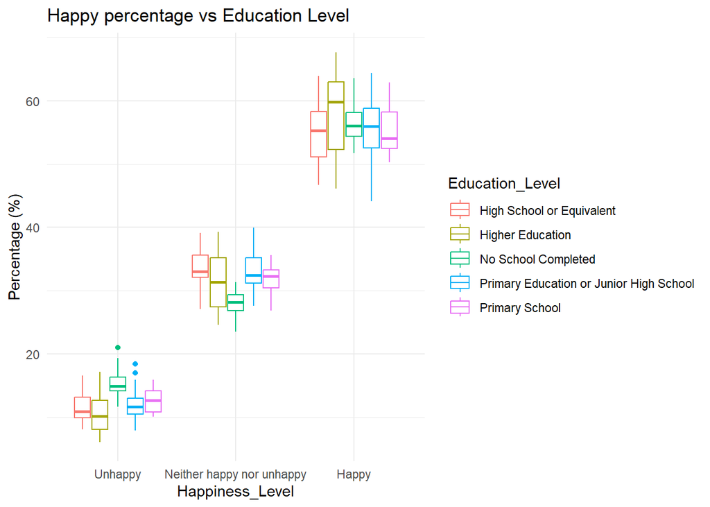

```r
 byeducation |>
  select(everything()) |>
  pivot_longer(cols = c("No School Completed","Primary School","Primary Education or Junior High School","High School or Equivalent","Higher Education"), names_to = "Education_Level", values_to = "Percentage") |>ggplot(aes(x = Happiness_Level, y = Percentage, color = Education_Level)) +
  geom_boxplot() +
  labs(title = "Happy percentage vs Education Level",
       x = "Happiness_Level", y = "Percentage (%)", color = "Education_Level") +
  theme_minimal()
```

To provide a more detailed analysis of the “bygender” dataset, the following questions will be examined.

To closely examine the dataset, the first step is to explore the relationship between education levels and happiness levels. *Question: How does the percentage of happiness vary for each gender?*

Based on the results obtained, the following observations can be made:

- Within a given year, the distribution of happiness levels across genders shows similar proportions for both men and women.
- **Women** report the highest average life satisfaction **“Happy”**, while men tend to have the lowest average satisfaction.
- The majority of individuals who identify as **“Unhappy”** are **men**.
- There is a **notable difference** between the average happiness percentages for men and women, particularly at the **“Happy” level**.

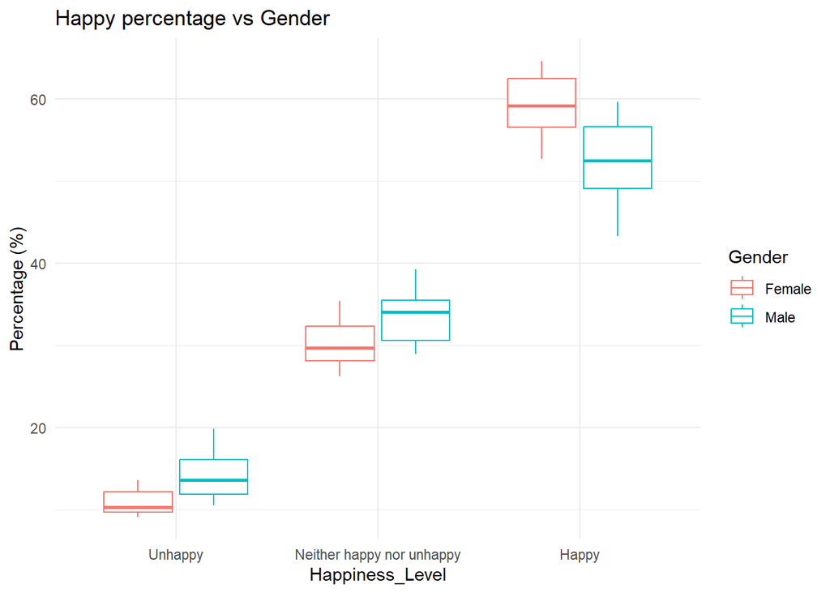

```r
 bygender |>
  select( everything()) |>
  pivot_longer(cols = c("Male", "Female"), names_to = "Gender", values_to = "Percentage") |>ggplot(aes(x = Happiness_Level, y = Percentage, color = Gender)) +
  geom_boxplot()+
  labs(title = "Happy percentage vs Gender",
       x = "Happiness_Level", y = "Percentage (%)", color = "Gender") +
  theme_minimal()
```

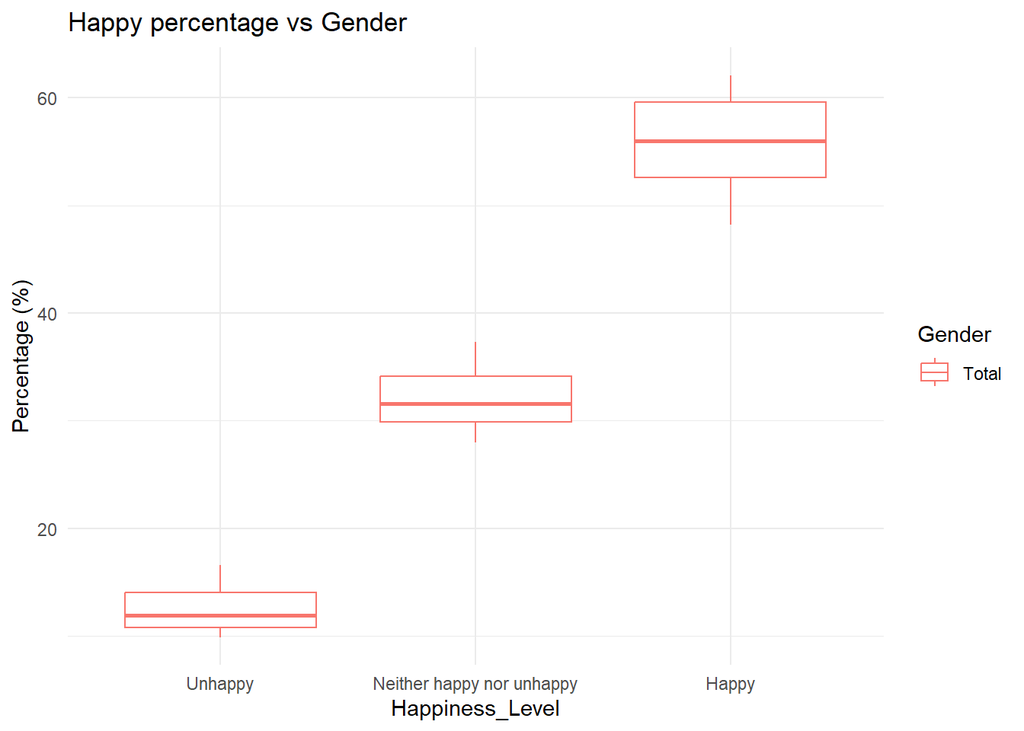

```r
 bygender |>
  select( everything()) |>
  pivot_longer(cols = c("Total"), names_to = "Gender", values_to = "Percentage") |>ggplot(aes(x = Happiness_Level, y = Percentage, color = Gender)) +
  geom_boxplot()+
  labs(title = "Happy percentage vs Gender",
       x = "Happiness_Level", y = "Percentage (%)", color = "Gender") +
  theme_minimal()
```

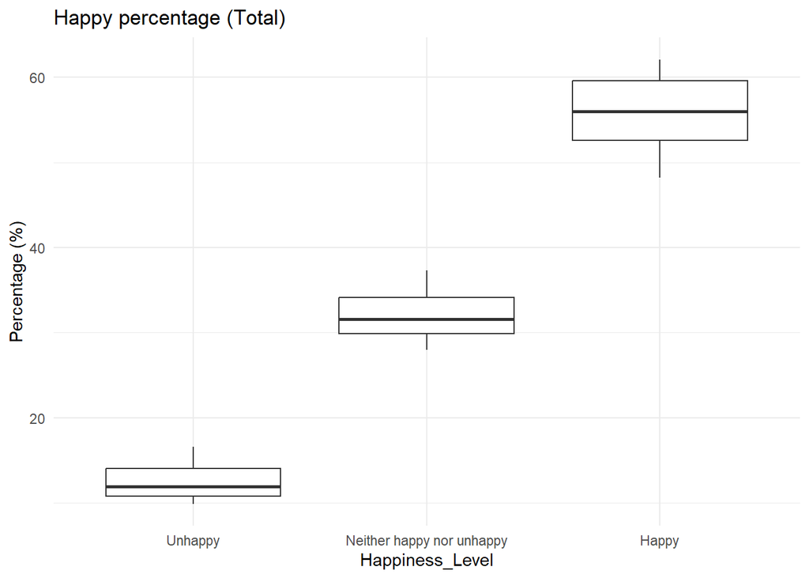

```r
bygender|> ggplot(aes(x=Happiness_Level,y=Total))+geom_boxplot()+
  labs(title = "Happy percentage (Total)",
       x = "Happiness_Level", y = "Percentage (%)") +
  theme_minimal()
```

## 3.2 Trend Analysis

In this section, the behavior of different variables within the datasets over time will be examined. As in previous sections, the datasets will be analyzed separately, and the time-dependent behavior of the variables will be explored by addressing various research questions.

**Analysis for “education” dataset**

In the previous sections, we examined the top 10 provinces with the highest number of university graduates over different years. As the next step in the analysis, we can investigate the provinces where the rate of university graduates has increased most rapidly. *Question: In which provinces has the rate of university graduates increased most rapidly?*

Based on the chart below, the following observations can be made:

- Consistent with our earlier findings, provinces such as Istanbul and Ankara, which appeared in the previous analysis, are also among the provinces that have shown the fastest growth in the number of individuals with higher education. One possible explanation for this is the large population size of these cities.
- **Istanbul**, the province with the highest number of university graduates, has shown a **steady increase between 2008 and 2023**. Similarly, **Izmir** has also demonstrated consistent growth.
- A particularly noteworthy observation is the **sharp upward trend in Ankara**, especially **after 2020**, where the growth rate increased significantly. A similar observation can be made for **Konya** and **Bursa**, though the growth rate in these cities is somewhat slower. This rapid increase, particularly after 2020, may be attributed to the growth in the number of universities in these cities and the migration they have received in recent years.

```r
univ_trend <- education |>
  filter(Educational_Status == "Higher Education") |>
  mutate(Total = Male + Female)

slope_by_province <- univ_trend %>%
  group_by(Province) %>%
  summarise(slope = coef(lm(Total ~ Year))[2]) %>%
  arrange(desc(slope))

head(slope_by_province, 10)
```

```
# A tibble: 10 × 2
   Province    slope
   <chr>       <dbl>
 1 İSTANBUL  166314.
 2 ANKARA     92572.
 3 İZMİR      55971.
 4 BURSA      29044.
 5 KONYA      23179.
 6 ADANA      23058.
 7 KOCAELİ    22834.
 8 ANTALYA    21437.
 9 MERSİN     19919.
10 ESKİŞEHİR  16730.
```

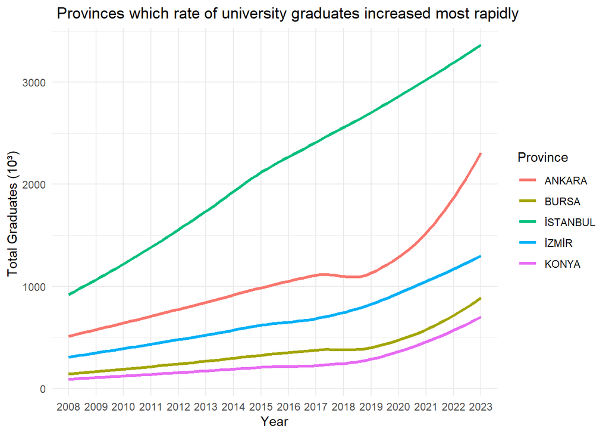

```r
top_provinces <- slope_by_province %>%
  slice_max(order_by = slope, n = 5) %>%
  pull(Province)

univ_trend %>%
  filter(Province %in% top_provinces) %>%
  ggplot(aes(x = Year, y = Total/1000, color = Province, group = Province)) +
  geom_smooth(method = "loess", se = FALSE, linewidth = 1.2) +
  labs(title = " Provinces which rate of university graduates increased most rapidly",
       x = "Year", y = "Total Graduates (10³) ") +
  theme_minimal()
```

**Analysis for “bygender” dataset**

In the next step of our analysis, we can consider how life satisfaction has evolved over time for both men and women, based on the previously explored relationship between gender and happiness levels. *Question: How has life satisfaction changed over time for men and women?*

Based on the chart below and in line with our earlier findings, the following observations can be made:

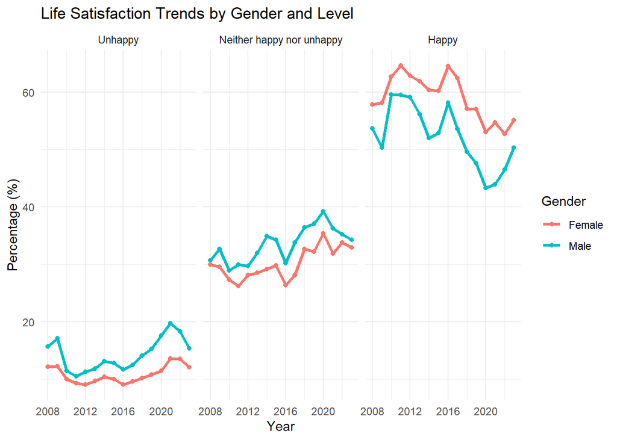

```r
bygender_long <- bygender |>
  pivot_longer(cols = c("Male", "Female"),
               names_to = "Gender",
               values_to = "Percentage")
ggplot(bygender_long, aes(x = Year, y = Percentage, color = Gender)) +
  geom_line(size = 1.2) +
  geom_point(linewidth = 2) +
  facet_wrap(~ Happiness_Level) +
  labs(title = "Life Satisfaction Trends by Gender and Level",
       x = "Year", y = "Percentage (%)",
       color = "Gender") +
  theme_minimal()
```

We can conclude that there is a significant difference between men and women in terms of happiness levels. This conclusion can be further developed by examining whether the difference between men and women persists annually. *Question: Does the difference in life satisfaction between men and women persist annually?*

Based on the analysis below, the following observations can be made:

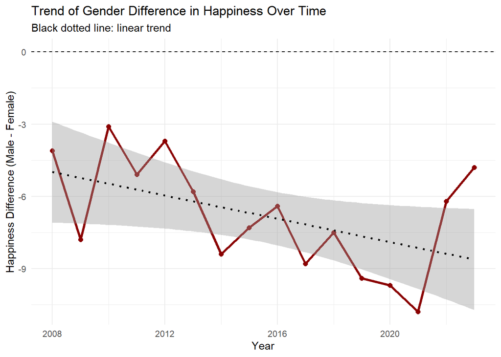

```r
mutlu_df <- bygender |>
  filter(Happiness_Level == "Happy") |>
  pivot_longer(cols = c(Male, Female),
               names_to = "Gender",
               values_to = "Percentage")|>
  pivot_wider(names_from = Gender, values_from = Percentage)|>
  mutate(Difference = Male - Female)

  ggplot(mutlu_df, aes(x = Year, y = Difference)) +
  geom_line(color = "darkred", size = 1.2) +
  geom_point(size = 2, color = "darkred") +
  geom_hline(yintercept = 0, linetype = "dashed") +
  geom_smooth(method = "lm", se = TRUE, color = "black", linetype = "dotted") +
  labs(title = "Trend of Gender Difference in Happiness Over Time",
       subtitle = "Black dotted line: linear trend",
       x = "Year", y = "Happiness Difference (Male - Female)") +
  theme_minimal()
```

```r
model <- lm(Difference ~ Year, data = mutlu_df)
summary(model)
```

```
Call:
lm(formula = Difference ~ Year, data = mutlu_df)

Residuals:
    Min      1Q  Median      3Q     Max
-2.6632 -1.7616  0.1562  1.2136  3.8206

Coefficients:
            Estimate Std. Error t value Pr(>|t|)
(Intercept) 480.7669   223.5764   2.150   0.0495 *
Year         -0.2419     0.1109  -2.181   0.0468 *
---
Signif. codes:  0 '***' 0.001 '**' 0.01 '*' 0.05 '.' 0.1 ' ' 1

Residual standard error: 2.045 on 14 degrees of freedom
Multiple R-squared:  0.2536,    Adjusted R-squared:  0.2003
F-statistic: 4.756 on 1 and 14 DF,  p-value: 0.04675
```

Similarly, the difference in happiness levels between men and women at the **“Unhappy” level** has also been examined for statistical **significance**. According to the results, since **p = 0.0268**, which is less than 0.05, the difference is statistically significant. On average, the difference between men and women in the “Unhappy” category **increases by 0.17** points per year.

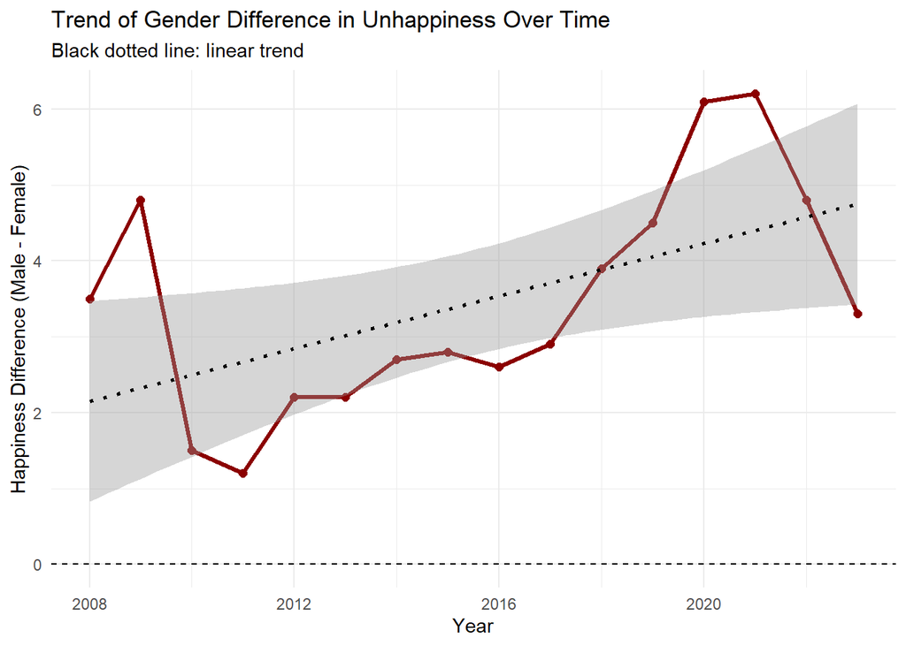

```r
mutsuz_df <- bygender |>
  filter(Happiness_Level == "Unhappy") |>
  pivot_longer(cols = c(Male, Female),
               names_to = "Gender",
               values_to = "Percentage")|>
  pivot_wider(names_from = Gender, values_from = Percentage)|>
  mutate(Difference = Male - Female)

  ggplot(mutsuz_df, aes(x = Year, y = Difference)) +
  geom_line(color = "darkred", size = 1.2) +
  geom_point(size = 2, color = "darkred") +
  geom_hline(yintercept = 0, linetype = "dashed") +
  geom_smooth(method = "lm", se = TRUE, color = "black", linetype = "dotted") +
  labs(title = "Trend of Gender Difference in Unhappiness Over Time",
       subtitle = "Black dotted line: linear trend",
       x = "Year", y = "Happiness Difference (Male - Female)") +
  theme_minimal()
```

```r
model <- lm(Difference ~ Year, data = mutsuz_df)
summary(model)
```

```
Call:
lm(formula = Difference ~ Year, data = mutsuz_df)

Residuals:
    Min      1Q  Median      3Q     Max
-1.4704 -0.8468 -0.5268  0.6701  2.4760

Coefficients:
              Estimate Std. Error t value Pr(>|t|)
(Intercept) -345.70574  141.18345  -2.449   0.0281 *
Year           0.17324    0.07005   2.473   0.0268 *
---
Signif. codes:  0 '***' 0.001 '**' 0.01 '*' 0.05 '.' 0.1 ' ' 1

Residual standard error: 1.292 on 14 degrees of freedom
Multiple R-squared:  0.304, Adjusted R-squared:  0.2543
F-statistic: 6.116 on 1 and 14 DF,  p-value: 0.02683
```

**Analysis for “byeducation” dataset**

We have previously gathered some insights regarding the relationship between education levels and happiness levels in the dataset. As the next step in this analysis, we can consider how life satisfaction has evolved over time for different education levels. *Question: How has life satisfaction percentage changed over level of education?*

```r
edu_happy <- byeducation |>
  filter(Happiness_Level=="Happy")|>pivot_longer(c(`No School Completed`,`Primary School`,`Primary Education or Junior High School`,`High School or Equivalent`,`Higher Education`),
               names_to  = "Educational_Status",
               values_to = "Percentage")

edu_happy$Educational_Status <- factor(
  edu_happy$Educational_Status,
  levels = c("No School Completed","Primary School","Primary Education or Junior High School","High School or Equivalent","Higher Education",order=TRUE)
)

edu_trends <- edu_happy %>%
  group_by(Educational_Status) %>%
  do(tidy(lm(Percentage ~ Year, data = .))) %>%
  filter(term == "Year") %>%
  arrange(desc(estimate))

edu_trends |> kbl() |> kable_styling()
```

| Educational_Status | term | estimate | std.error | statistic | p.value |
| --- | --- | --- | --- | --- | --- |
| No School Completed | Year | -0.0882828 | 0.1888264 | -0.4675341 | 0.6473120 |
| Primary School | Year | -0.3969668 | 0.1949510 | -2.0362384 | 0.0611031 |
| High School or Equivalent | Year | -0.8323926 | 0.2130358 | -3.9072905 | 0.0015789 |
| Primary Education or Junior High School | Year | -0.8840392 | 0.2311315 | -3.8248326 | 0.0018575 |
| Higher Education | Year | -1.3692589 | 0.1712698 | -7.9947499 | 0.0000014 |

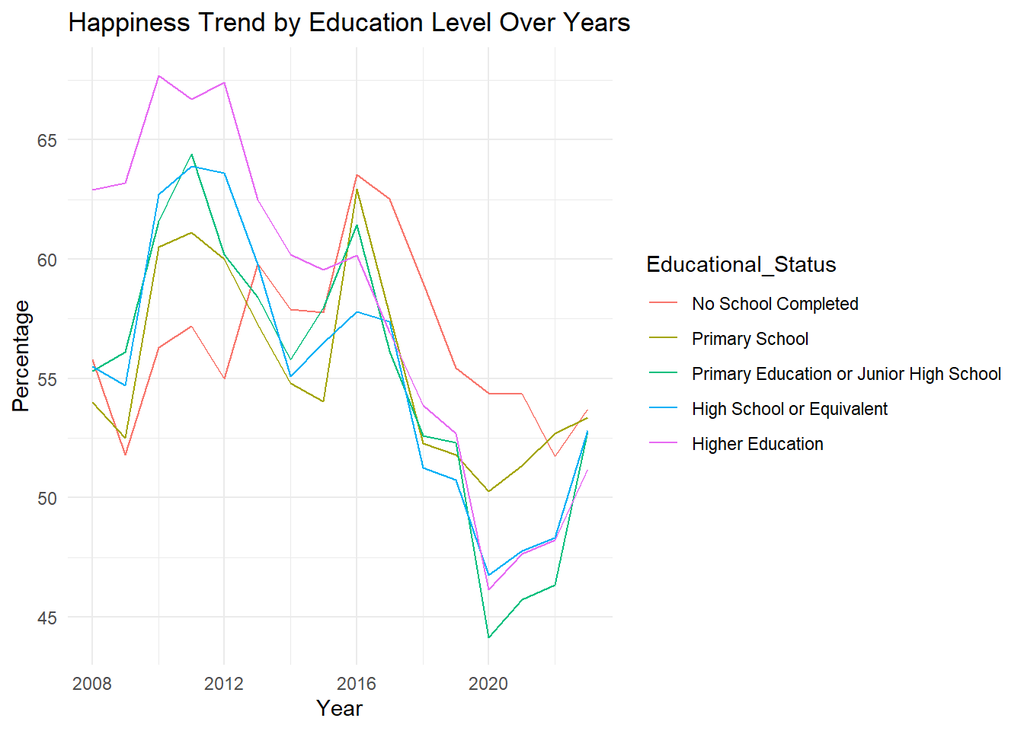

```r
ggplot(edu_happy, aes(x = Year, y = Percentage, color = Educational_Status)) +
  geom_line() +
  labs(title = "Happiness Trend by Education Level Over Years")+
  theme_minimal()
```

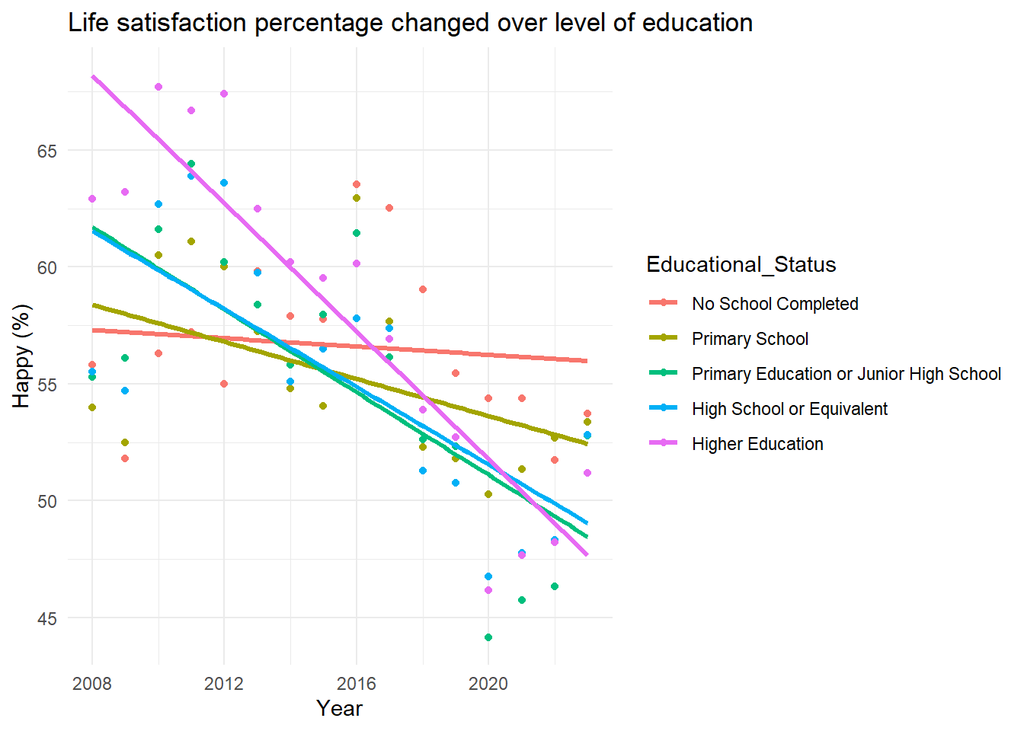

```r
ggplot(edu_happy, aes(x = Year, y = Percentage, color = Educational_Status)) +
 geom_point() +
  geom_smooth(method = "lm", se = FALSE, size = 1.2) +
  labs(title = "Life satisfaction percentage changed over level of education",
       x = "Year", y = "Happy (%)") +
  theme_minimal()
```

The same analysis has been conducted for the “Unhappy” happiness level, and the following results were found:

- The percentage of individuals who identify as **“Unhappy”** has **increased** over time for all education levels, **except for those without any education**.
- For individuals **without any education**, the percentage of those who identify as “Unhappy” has decreased over time, with an average **decrease of 0.065** per year.
- The education level with the **largest increase** in the percentage of individuals who identify as **“Unhappy” over time is higher education**. For this group, the percentage of those who report being “Unhappy” has increased by an average of **0.45** points per year.

```r
edu_unhappy <- byeducation |>
  filter(Happiness_Level=="Unhappy")|>pivot_longer(c(`No School Completed`,`Primary School`,`Primary Education or Junior High School`,`High School or Equivalent`,`Higher Education`),
               names_to  = "Educational_Status",
               values_to = "Percentage")

edu_unhappy$Educational_Status <- factor(
  edu_unhappy$Educational_Status,
  levels = c("No School Completed","Primary School","Primary Education or Junior High School","High School or Equivalent","Higher Education",order=TRUE)
)

edu_trends <- edu_unhappy %>%
  group_by(Educational_Status) %>%
  do(tidy(lm(Percentage ~ Year, data = .))) %>%
  filter(term == "Year") %>%
  arrange(desc(estimate))

edu_trends |> kbl() |> kable_styling()
```

| Educational_Status | term | estimate | std.error | statistic | p.value |
| --- | --- | --- | --- | --- | --- |
| Higher Education | Year | 0.4521631 | 0.1235502 | 3.6597527 | 0.0025746 |
| Primary Education or Junior High School | Year | 0.3733905 | 0.1286275 | 2.9028818 | 0.0115759 |
| High School or Equivalent | Year | 0.3401795 | 0.1121412 | 3.0334923 | 0.0089378 |
| Primary School | Year | 0.1823240 | 0.0966591 | 1.8862576 | 0.0801774 |
| No School Completed | Year | -0.0656706 | 0.1318412 | -0.4981037 | 0.6261441 |

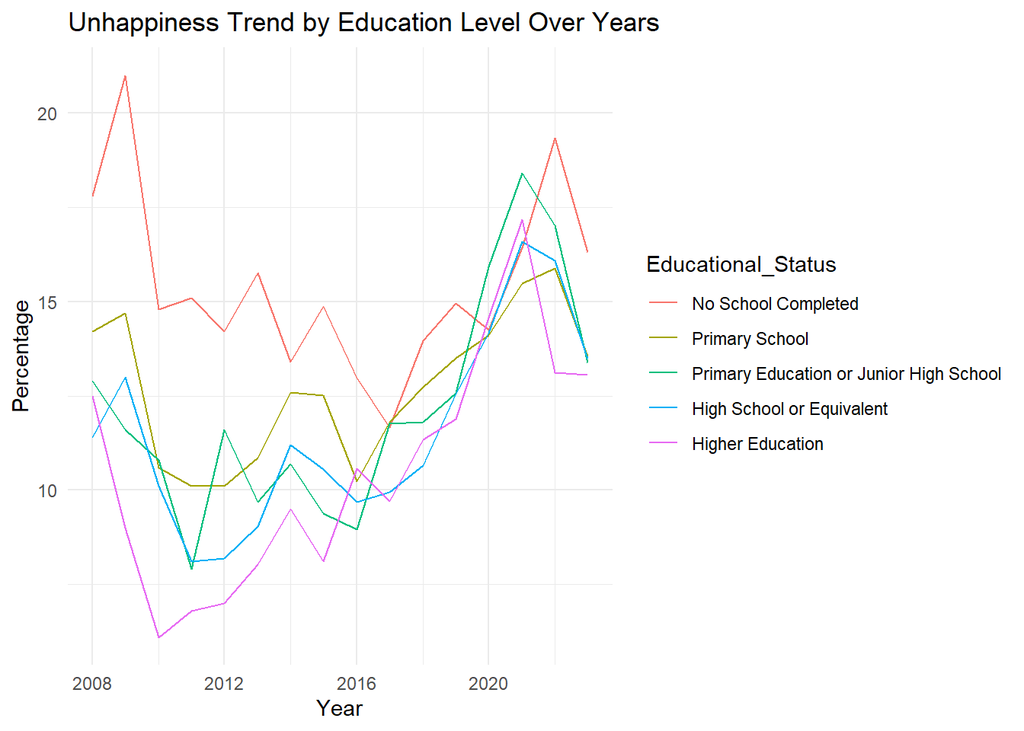

```r
ggplot(edu_unhappy, aes(x = Year, y = Percentage, color = Educational_Status)) +
  geom_line() +
  labs(title = "Unhappiness Trend by Education Level Over Years")+
  theme_minimal()
```

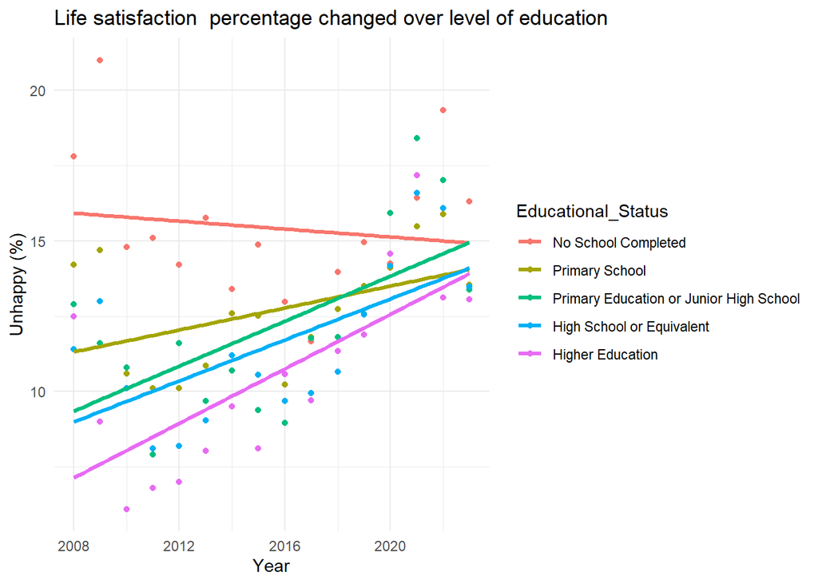

```r
ggplot(edu_unhappy, aes(x = Year, y = Percentage, color = Educational_Status)) +
 geom_point() +
  geom_smooth(method = "lm", se = FALSE, size = 1.2) +
  labs(title = "Life satisfaction  percentage changed over level of education",
       x = "Year", y = "Unhappy (%)") +
  theme_minimal()
```

## 3.3 Model Fitting

In this section, the primary objective of the research will be addressed by statistically examining the relationships between variables that influence individuals’ happiness levels, their interconnections, and their association with happiness levels in more detail. Based on the findings, predictive models for the future will be developed. This approach will be carried out, as in previous steps, by answering key questions.

- *Question: Is there a significant difference between educational level and happiness level? (using the “byeducation” dataset)*

According to the Chi-square test[3], the **p-value is 2.2e-16**, which is less than 0.05. Therefore, it can be concluded that happiness levels are **significantly** associated with **education level**.

```r
#
df<- byeducation |> pivot_longer(c(`No School Completed`,`Primary School`,`Primary Education or Junior High School`,`High School or Equivalent`,`Higher Education`),
               names_to  = "Educational_Status",
               values_to = "Percentage") |>
 mutate(Estimated_Count = round(Percentage * 1000 / 100))


summary_table <- df %>%
  group_by(Happiness_Level, Educational_Status) %>%
  summarise(Count = sum(Estimated_Count), .groups = "drop")

contingency_matrix <- summary_table %>%
  pivot_wider(names_from = Happiness_Level, values_from = Count) %>%
  column_to_rownames("Educational_Status") %>%
  as.matrix()
chisq.test(contingency_matrix)
```

```
    Pearson's Chi-squared test

data:  contingency_matrix
X-squared = 277.05, df = 8, p-value < 2.2e-16
```

- *Question: Is there a significant difference between gender and happiness level? (using the “bygender” dataset)*

According to the Chi-square test, the **p-value is 2.2e-16**, which is less than 0.05. Therefore, it can be concluded that happiness levels are **significantly** associated with **gender**.

```r
#
df1<- bygender |> pivot_longer(c(Male,Female),
               names_to  = "Gender",
               values_to = "Percentage") |>
 mutate(Estimated_Count = round(Percentage * 1000 / 100))


summary_table <- df1 %>%
  group_by(Happiness_Level, Gender) %>%
  summarise(Count = sum(Estimated_Count), .groups = "drop")

contingency_matrix1 <- summary_table %>%
  pivot_wider(names_from = Happiness_Level, values_from = Count) %>%
  column_to_rownames("Gender") %>%
  as.matrix()
chisq.test(contingency_matrix1)
```

```
    Pearson's Chi-squared test

data:  contingency_matrix1
X-squared = 170.61, df = 2, p-value < 2.2e-16
```

- It has once again been observed that **happiness level (Happy) is influenced by both education level and gender**. In the next stage of the analysis, separate predictive models were developed to estimate happiness levels based on education and gender variables.

**Education Level-Based Happiness Level Prediction Model;**

A predictive model for estimating the percentage of individuals who report being happy based on education level can be constructed in three different ways:

- **Model 1** assumes that happiness is influenced solely by **education level**.
- **Model 2** includes the **effect of time (year)** in addition to education level.
- **Model 3** incorporates the **interaction** between education level and time.

Based on the results, when comparing the Akaike Information Criterion (AIC)[4] values of the models, **Model 3** was found to have the **lowest AIC**, indicating the **best fit to the data**. This suggests that the **interaction between education level and year should be included** in the predictive model for estimating happiness levels.

Accordingly, the final model should include the statistically **significant** education levels — **Primary Education or Junior High School**, **High School**, and **Higher Education** — as well as their **interactions with the year** variable. Since the “Education_Level” variable is categorical, a reference category is selected when constructing the model[5], which is typically the first level. In this case, the reference category is the “No School Completed” category. The “Intercept”($\beta_0$) value in the model output represents the average happiness percentage for “No School Completed” category, while the Other coefficients represent the difference between the average happiness percentage of the relevant education level and that of the ‘No School Completed’ category.

According to the model created, the percentages of happiness by education levels between 2024 and 2028 are estimated as follows and shown on the graph. Parallel to previous findings, it is predicted that happiness rates will decrease for all education levels.

The adequacy of the model was validated by analyzing whether the residuals conform to a normal distribution with Q-Q Plot and Anderson-Darling Normality Test[6].

```r
happy_df_byeducation  <- byeducation|>
  pivot_longer(
    cols = -c(Year, Happiness_Level),
    names_to = "Education_Level",
    values_to = "Percentage"
  ) |>
  filter(Happiness_Level == "Happy")|>
mutate(Education_Level = factor(Education_Level,
                                  levels = c("No School Completed","Primary School","Primary Education or Junior High School","High School or Equivalent","Higher Education",order=TRUE)
))

model1 <- lm(Percentage ~ Education_Level, data = happy_df_byeducation)
summary(model1)
```

```
Call:
lm(formula = Percentage ~ Education_Level, data = happy_df_byeducation)

Residuals:
    Min      1Q  Median      3Q     Max
-11.789  -2.971   0.011   3.602   9.761

Coefficients:
                                                       Estimate Std. Error
(Intercept)                                              56.642      1.340
Education_LevelPrimary School                            -1.233      1.895
Education_LevelPrimary Education or Junior High School   -1.565      1.895
Education_LevelHigh School or Equivalent                 -1.353      1.895
Education_LevelHigher Education                           1.296      1.895
                                                       t value Pr(>|t|)
(Intercept)                                             42.262   <2e-16 ***
Education_LevelPrimary School                           -0.650    0.517
Education_LevelPrimary Education or Junior High School  -0.826    0.412
Education_LevelHigh School or Equivalent                -0.714    0.477
Education_LevelHigher Education                          0.684    0.496
---
Signif. codes:  0 '***' 0.001 '**' 0.01 '*' 0.05 '.' 0.1 ' ' 1

Residual standard error: 5.361 on 75 degrees of freedom
Multiple R-squared:  0.04162,   Adjusted R-squared:  -0.009497
F-statistic: 0.8142 on 4 and 75 DF,  p-value: 0.5201
```

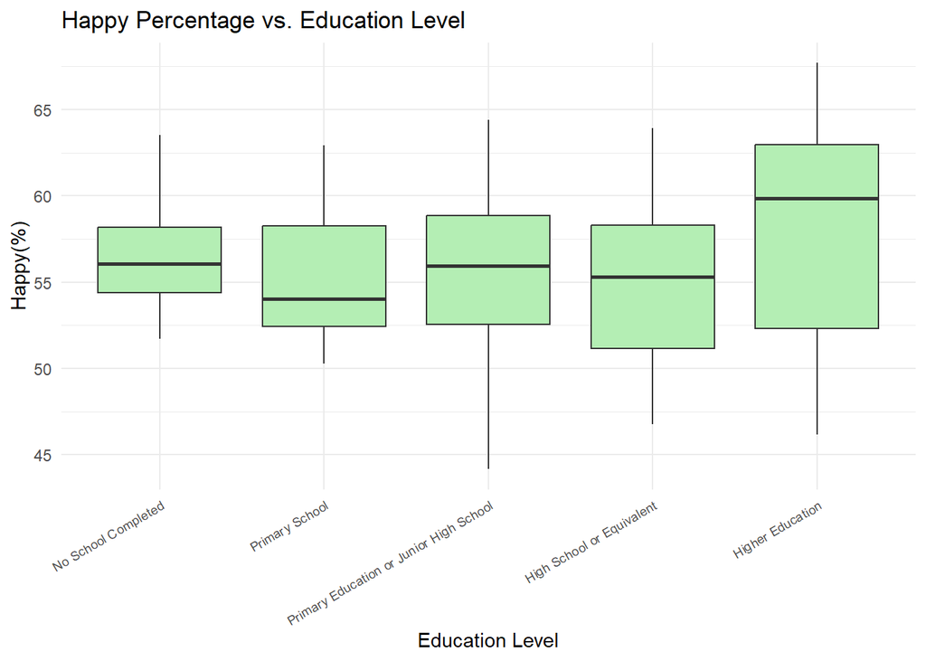

```r
ggplot(happy_df_byeducation, aes(x = Education_Level, y = Percentage)) +
  geom_boxplot(fill = "darkseagreen2") +
  labs(title = "Happy Percentage vs. Education Level",
       x = "Education Level", y = "Happy(%)") +
  theme_minimal()+
  theme(axis.text.x = element_text(angle = 30, hjust = 1, size = 7))
```

```r
model2 <- lm(Percentage ~ Education_Level + Year, data = happy_df_byeducation)
summary(model2)
```

```
Call:
lm(formula = Percentage ~ Education_Level + Year, data = happy_df_byeducation)

Residuals:
    Min      1Q  Median      3Q     Max
-9.4845 -2.4151  0.4029  2.6386  7.8886

Coefficients:
                                                        Estimate Std. Error
(Intercept)                                            1496.0883   203.9767
Education_LevelPrimary School                            -1.2328     1.4753
Education_LevelPrimary Education or Junior High School   -1.5648     1.4753
Education_LevelHigh School or Equivalent                 -1.3533     1.4753
Education_LevelHigher Education                           1.2962     1.4753
Year                                                     -0.7142     0.1012
                                                       t value Pr(>|t|)
(Intercept)                                              7.335 2.33e-10 ***
Education_LevelPrimary School                           -0.836    0.406
Education_LevelPrimary Education or Junior High School  -1.061    0.292
Education_LevelHigh School or Equivalent                -0.917    0.362
Education_LevelHigher Education                          0.879    0.382
Year                                                    -7.057 7.70e-10 ***
---
Signif. codes:  0 '***' 0.001 '**' 0.01 '*' 0.05 '.' 0.1 ' ' 1

Residual standard error: 4.173 on 74 degrees of freedom
Multiple R-squared:  0.4271,    Adjusted R-squared:  0.3884
F-statistic: 11.04 on 5 and 74 DF,  p-value: 5.843e-08
```

```r
model3 <- lm(Percentage ~ Education_Level * Year, data = happy_df_byeducation)
summary(model3)
```

```
Call:
lm(formula = Percentage ~ Education_Level * Year, data = happy_df_byeducation)

Residuals:
    Min      1Q  Median      3Q     Max
-6.9436 -2.1574  0.0044  2.6583  7.7300

Coefficients:
                                                              Estimate
(Intercept)                                                  234.57621
Education_LevelPrimary School                                620.91983
Education_LevelPrimary Education or Junior High School      1602.28219
Education_LevelHigh School or Equivalent                    1498.40007
Education_LevelHigher Education                             2583.10352
Year                                                          -0.08828
Education_LevelPrimary School:Year                            -0.30868
Education_LevelPrimary Education or Junior High School:Year   -0.79576
Education_LevelHigh School or Equivalent:Year                 -0.74411
Education_LevelHigher Education:Year                          -1.28098
                                                            Std. Error t value
(Intercept)                                                  404.91157   0.579
Education_LevelPrimary School                                572.63143   1.084
Education_LevelPrimary Education or Junior High School       572.63143   2.798
Education_LevelHigh School or Equivalent                     572.63143   2.617
Education_LevelHigher Education                              572.63143   4.511
Year                                                           0.20090  -0.439
Education_LevelPrimary School:Year                             0.28411  -1.086
Education_LevelPrimary Education or Junior High School:Year    0.28411  -2.801
Education_LevelHigh School or Equivalent:Year                  0.28411  -2.619
Education_LevelHigher Education:Year                           0.28411  -4.509
                                                            Pr(>|t|)
(Intercept)                                                  0.56423
Education_LevelPrimary School                                0.28194
Education_LevelPrimary Education or Junior High School       0.00663 **
Education_LevelHigh School or Equivalent                     0.01087 *
Education_LevelHigher Education                             2.53e-05 ***
Year                                                         0.66170
Education_LevelPrimary School:Year                           0.28099
Education_LevelPrimary Education or Junior High School:Year  0.00658 **
Education_LevelHigh School or Equivalent:Year                0.01080 *
Education_LevelHigher Education:Year                        2.56e-05 ***
---
Signif. codes:  0 '***' 0.001 '**' 0.01 '*' 0.05 '.' 0.1 ' ' 1

Residual standard error: 3.704 on 70 degrees of freedom
Multiple R-squared:  0.5729,    Adjusted R-squared:  0.518
F-statistic: 10.43 on 9 and 70 DF,  p-value: 4.852e-10
```

```r
AIC(model1, model2, model3)
```

```
       df      AIC
model1  6 502.5322
model2  7 463.3631
model3 11 447.8703
```

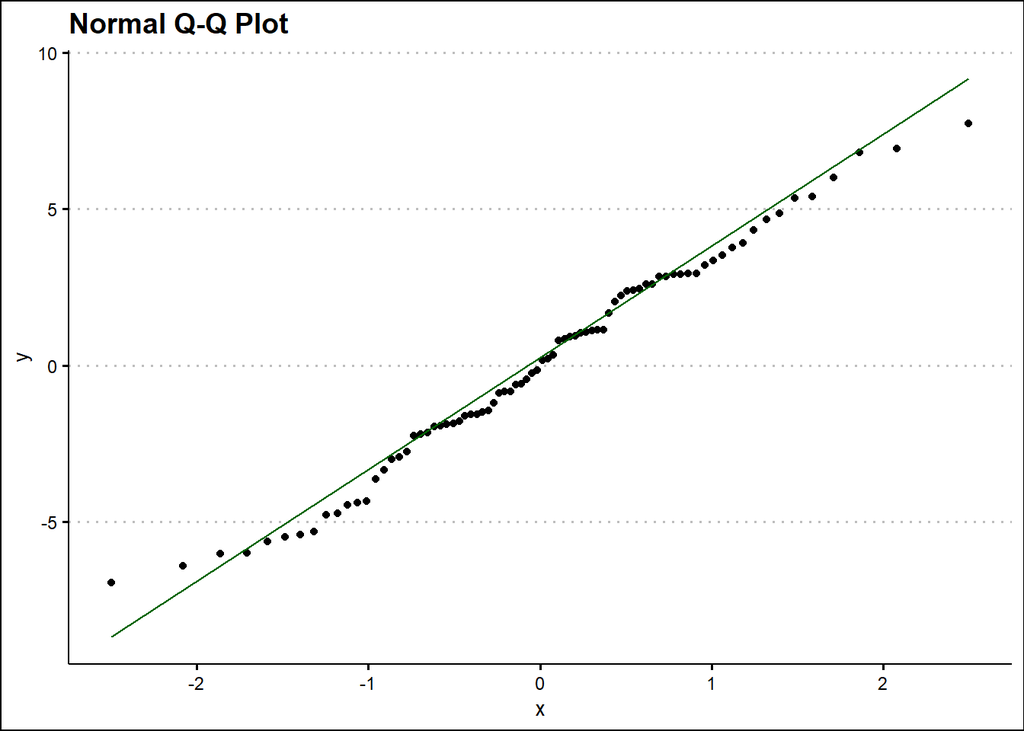

```r
ggplot(happy_df_byeducation, aes(sample = resid(model3))) +
  stat_qq() +
  stat_qq_line(color = "darkgreen") +
  labs(title = "Normal Q-Q Plot") +
  theme_clean()
```

```r
residuals <- resid(model3)

ad_test_results <- ad.test(residuals)
print(ad_test_results)
```

```
    Anderson-Darling normality test

data:  residuals
A = 0.31572, p-value = 0.5353
```

```r
edu_predict<-data.frame(Education_Level = factor(
    c("No School Completed",
      "Primary School",
      "Primary Education or Junior High School",
      "High School or Equivalent",
      "Higher Education"),
    levels = levels(happy_df_byeducation$Education_Level)
  ),Year=rep(2024:2028,each=5)
)
Prediction<-data.frame(Prediction=predict(model3, newdata = edu_predict))
edu_predict<-bind_cols(edu_predict,Prediction)
kbl(edu_predict) |> kable_styling(full_width = 5)
```

| Education_Level | Year | Prediction |
| --- | --- | --- |
| No School Completed | 2024 | 55.89188 |
| Primary School | 2024 | 52.03531 |
| Primary Education or Junior High School | 2024 | 47.56311 |
| High School or Equivalent | 2024 | 48.21365 |
| Higher Education | 2024 | 46.29979 |
| No School Completed | 2025 | 55.80360 |
| Primary School | 2025 | 51.63834 |
| Primary Education or Junior High School | 2025 | 46.67907 |
| High School or Equivalent | 2025 | 47.38126 |
| Higher Education | 2025 | 44.93053 |
| No School Completed | 2026 | 55.71532 |
| Primary School | 2026 | 51.24137 |
| Primary Education or Junior High School | 2026 | 45.79503 |
| High School or Equivalent | 2026 | 46.54887 |
| Higher Education | 2026 | 43.56127 |
| No School Completed | 2027 | 55.62704 |
| Primary School | 2027 | 50.84441 |
| Primary Education or Junior High School | 2027 | 44.91099 |
| High School or Equivalent | 2027 | 45.71647 |
| Higher Education | 2027 | 42.19201 |
| No School Completed | 2028 | 55.53875 |
| Primary School | 2028 | 50.44744 |
| Primary Education or Junior High School | 2028 | 44.02695 |
| High School or Equivalent | 2028 | 44.88408 |
| Higher Education | 2028 | 40.82275 |

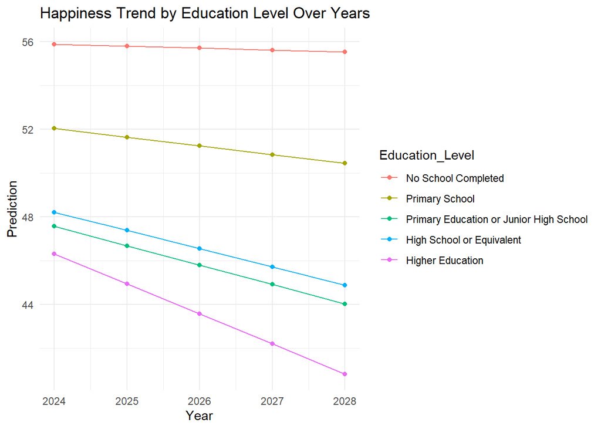

```r
ggplot(edu_predict, aes(x = Year, y = Prediction, color = Education_Level)) +
  geom_line() +
  geom_point()+
  scale_x_continuous(breaks = seq(min(edu_predict$Year), max(edu_predict$Year), by = 1))+
  labs(title = "Happiness Trend by Education Level Over Years")+
  theme_minimal()
```

**Gender-Based Happiness Level Prediction Model;**

The prediction model for happiness percentages based on gender can be established in three different ways.

- **Model 1** assumes that the happiness rate is only affected by **gender**.
- **Model 2** includes the **effect of time** in the prediction model.
- **Model 3** adds the **interaction** between gender and time to the prediction model.

Based on the results, when the AIC (Akaike Information Criterion) [4] values of the models are compared, it is observed that the model that best explains the data is **Model 2, which has the lowest AIC value**. Therefore, it can be concluded that the effect of the year should be included in the constructed prediction model.

Thus, in the prediction model for happiness percentage, the significant variables, **“GenderFemale”** (which takes a value of 0 for Male and 1 for Female) and **“Year”**, should be **included**. Since the “Gender” variable is categorical, a reference category is selected when constructing the model, which is typically the first level. In this case, the reference category is the “Male” category. The “Intercept”($\beta_0$) value in the model output represents the average happiness percentage for males, while the “GenderFemale” coefficient indicates the difference in the average happiness percentage between females and males.

According to the model created, the percentages of happiness by gender between 2024 and 2028 are estimated as follows and shown on the graph.Parallel to previous findings, it is predicted that happiness rates will decrease for both genders.

The adequacy of the model was validated by analyzing whether the residuals conform to a normal distribution with Q-Q Plot and Anderson-Darling Normality [6] Test.

```r
happy_df_bygender  <- bygender|>
  pivot_longer(cols = c("Male", "Female"),
               names_to = "Gender",
               values_to = "Percentage")|>
  filter(Happiness_Level == "Happy")|>
mutate(Gender = factor(Gender,levels = c("Male","Female")
))

model1 <- lm(Percentage ~ Gender, data = happy_df_bygender)
summary(model1)
```

```
Call:
lm(formula = Percentage ~ Gender, data = happy_df_bygender)

Residuals:
    Min      1Q  Median      3Q     Max
-8.9562 -2.9828  0.1938  3.6625  7.3438

Coefficients:
             Estimate Std. Error t value Pr(>|t|)
(Intercept)    52.256      1.171  44.619  < 2e-16 ***
GenderFemale    6.806      1.656   4.109 0.000283 ***
---
Signif. codes:  0 '***' 0.001 '**' 0.01 '*' 0.05 '.' 0.1 ' ' 1

Residual standard error: 4.685 on 30 degrees of freedom
Multiple R-squared:  0.3602,    Adjusted R-squared:  0.3388
F-statistic: 16.89 on 1 and 30 DF,  p-value: 0.0002825
```

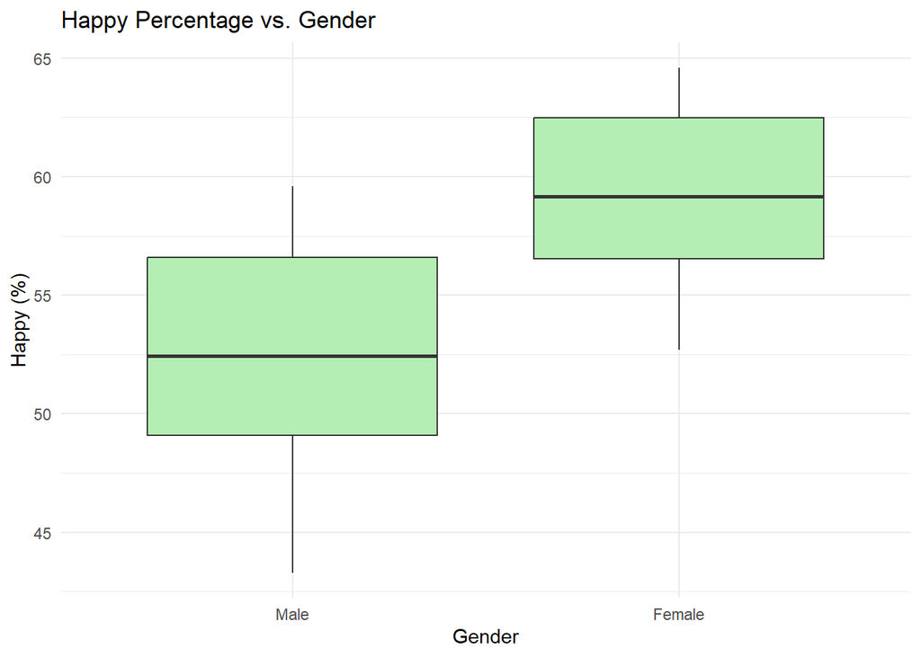

```r
ggplot(happy_df_bygender, aes(x = Gender, y = Percentage)) +
  geom_boxplot(fill = "darkseagreen2") +
  labs(title = "Happy Percentage vs. Gender",
       x = "Gender", y = "Happy (%)") +
  theme_minimal()
```

```r
model2 <- lm(Percentage ~ Gender+ Year, data = happy_df_bygender)
summary(model2)
```

```
Call:
lm(formula = Percentage ~ Gender + Year, data = happy_df_bygender)

Residuals:
    Min      1Q  Median      3Q     Max
-6.1588 -2.2183  0.2604  2.3922  6.1670

Coefficients:
              Estimate Std. Error t value Pr(>|t|)
(Intercept)  1355.3659   277.6201   4.882 3.52e-05 ***
GenderFemale    6.8063     1.2699   5.360 9.34e-06 ***
Year           -0.6465     0.1377  -4.694 5.94e-05 ***
---
Signif. codes:  0 '***' 0.001 '**' 0.01 '*' 0.05 '.' 0.1 ' ' 1

Residual standard error: 3.592 on 29 degrees of freedom
Multiple R-squared:  0.6364,    Adjusted R-squared:  0.6113
F-statistic: 25.38 on 2 and 29 DF,  p-value: 4.256e-07
```

```r
model3 <- lm(Percentage ~ Gender * Year, data = happy_df_bygender)
summary(model3)
```

```
Call:
lm(formula = Percentage ~ Gender * Year, data = happy_df_bygender)

Residuals:
    Min      1Q  Median      3Q     Max
-6.9450 -2.2140  0.1197  2.6519  6.2275

Coefficients:
                   Estimate Std. Error t value Pr(>|t|)
(Intercept)       1599.1525   394.2144   4.057 0.000361 ***
GenderFemale      -480.7669   557.5034  -0.862 0.395817
Year                -0.7675     0.1956  -3.924 0.000515 ***
GenderFemale:Year    0.2419     0.2766   0.875 0.389249
---
Signif. codes:  0 '***' 0.001 '**' 0.01 '*' 0.05 '.' 0.1 ' ' 1

Residual standard error: 3.607 on 28 degrees of freedom
Multiple R-squared:  0.6461,    Adjusted R-squared:  0.6081
F-statistic: 17.04 on 3 and 28 DF,  p-value: 1.716e-06
```

```r
AIC(model1, model2, model3)
```

```
       df      AIC
model1  3 193.5824
model2  4 177.4970
model3  5 178.6346
```

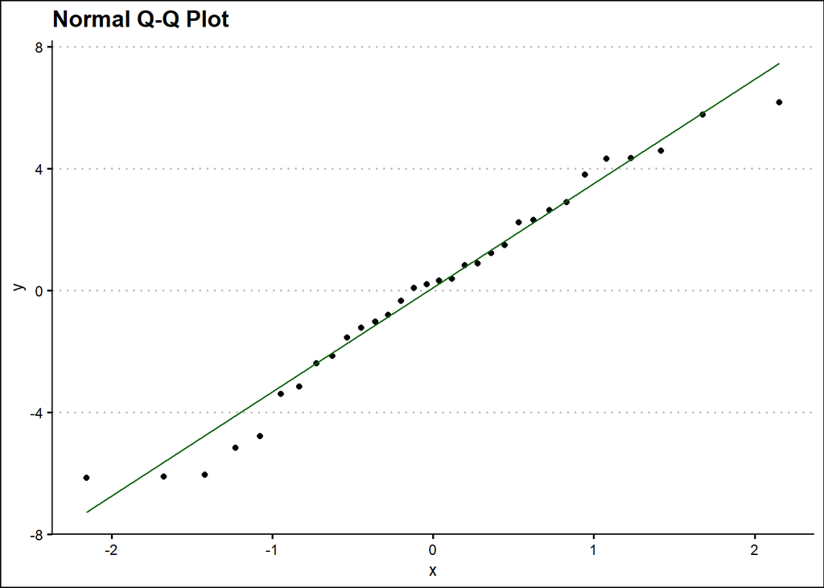

```r
ggplot(happy_df_bygender, aes(sample = resid(model2))) +
  stat_qq() +
  stat_qq_line(color = "darkgreen") +
  labs(title = "Normal Q-Q Plot") +
  theme_clean()
```

```r
residuals <- resid(model2)

ad_test_results <- ad.test(residuals)
print(ad_test_results)
```

```
    Anderson-Darling normality test

data:  residuals
A = 0.22885, p-value = 0.793
```

```r
gender_predict<-data.frame(Gender = factor(
    c("Male",
      "Female"),
    levels = levels(happy_df_bygender$Gender)
  ),Year=rep(2024:2028,each=2)
)
Prediction<-data.frame(Prediction=predict(model2, newdata = gender_predict))
gender_predict<-bind_cols(gender_predict,Prediction)
kbl(gender_predict) |> kable_styling(full_width = 5)
```

| Gender | Year | Prediction |
| --- | --- | --- |
| Male | 2024 | 46.76062 |
| Female | 2024 | 53.56688 |
| Male | 2025 | 46.11408 |
| Female | 2025 | 52.92033 |
| Male | 2026 | 45.46754 |
| Female | 2026 | 52.27379 |
| Male | 2027 | 44.82099 |
| Female | 2027 | 51.62724 |
| Male | 2028 | 44.17445 |
| Female | 2028 | 50.98070 |

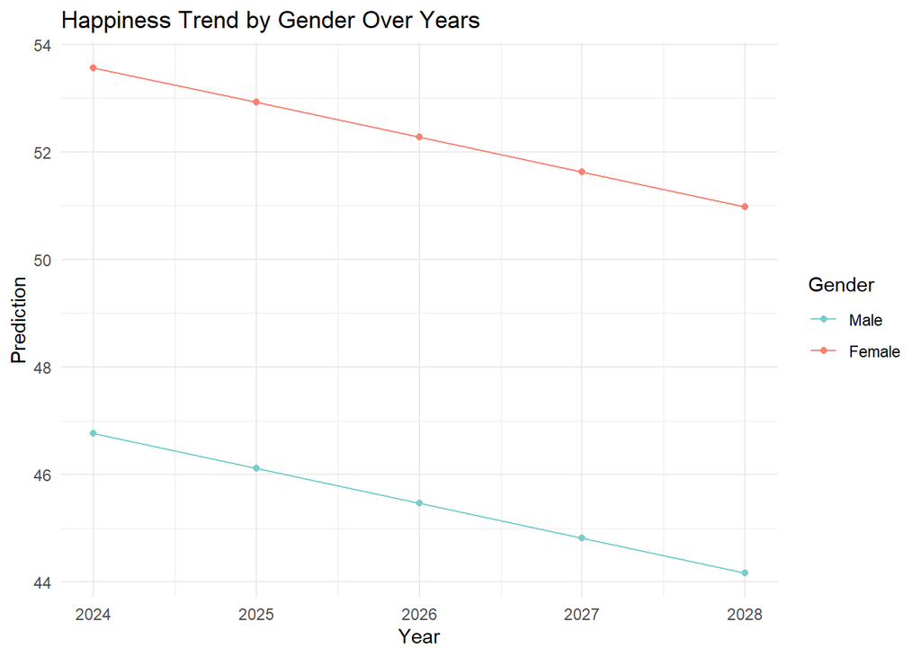

```r
ggplot(gender_predict, aes(x = Year, y = Prediction, color = Gender)) +
  geom_line() +
  geom_point()+
  scale_x_continuous(breaks = seq(min(gender_predict$Year), max(gender_predict$Year), by = 1))+
  scale_color_manual(values = c("Female" = "salmon", "Male" = "darkslategray3"))+
  labs(title = "Happiness Trend by Gender Over Years")+
  theme_minimal()
```

# 4. Results and Key Takeaways

[figure not shown]

In this study, three different datasets were analyzed to investigate the direction and magnitude of the effects of factors such as gender and educational attainment on individuals’ self-reported happiness. These datasets provide information on the total number of individuals by education level across different provinces of Turkey over the years, as well as gender distribution, and the levels of happiness individuals reported over time based on their education level and gender. The study was conducted using this information.

During the analysis phase, the first step involved examining the structure and trends of the variables to gain more detailed insight into the data. These initial observations were enriched further by exploring how the variables behaved over time. Finally, the effects of the variables on happiness percentages were discussed, and regression models based on gender and education level were developed to predict individuals’ likelihood of reporting happiness.

*Assistance from ChatGPT was utilized at certain parts of this study.

The mini research paper related to this study can be accessed here.

# References

1.Turkish Statistical Institute (TURKSTAT). “*Life Satisfaction Survey, 2023”*. Retrieved from https://data.tuik.gov.tr/ (accessed May, 2025)

2.Turkish Statistical Institute (TURKSTAT).(2024). “*Population Statics Portal, 2024”*. Retrieved from https://nip.tuik.gov.tr/ (accessed May, 2025)

3.K. Pearson, “*On the criterion that a given system of deviations from the probable in the case of a correlated system of variables is such that it can be reasonably supposed to have arisen from random sampling,*” The London, Edinburgh, and Dublin Philosophical Magazine and Journal of Science, vol. 50, no. 302, pp. 157–175, 1900.

4.H. Akaike, “*A new look at the statistical model identification,*” IEEE Transactions on Automatic Control, vol. 19, no. 6, pp. 716–723, 1974.

5.D. Firth and R. Menezes, “*Quasi-variances,*” Biometrika, vol. 91, no. 1, pp. 65–80, 2004.

6.T. W. Anderson and D. A. Darling, “*A test of goodness of fit,*” Journal of the American Statistical Association, vol. 49, no. 268, pp. 765–769, 1954.

Back to top